# Moral Dumbfounding and Cognitive Load

19 November 2021

## Overview

- Background: What is Dumbfounding
- Theoretical Approach
- Studies 1-5
- Study 6

## What is Moral Dumbfounding

## Heinz

In Europe, a woman was near death from a very bad disease, a special kind of cancer. There was one drug that the doctors thought might save her. It was a form of radium for which a druggist was charging ten times what the drug cost him to make. The sick woman’s husband, Heinz, went to everyone he knew to borrow the money, but he could only get together about half of what it cost. He told the druggist that his wife was dying, and asked him to sell it cheaper or let him pay later. But the druggist said, “No, I discovered the drug and I’m going to make money from it.” So, Heinz got desperate and broke into the man’s store to steal the drug for his wife. The druggist had Heinz arrested and charged.

## Trolley

A Trolley is hurtling down a track towards five people. It will kill them all on impact. Paul is on a bridge under which it will pass. He can stop it by putting something very heavy in front of it. As it happens, there is a very fat man next to him – Paul’s only way to stop the trolley is to push him over the bridge and onto the track, killing him to save five. Paul decides to push the man.

## Jennifer

Jennifer works in a medical school pathology lab as a research assistant. The lab prepares human cadavers that are used to teach medical students about anatomy. The cadavers come from people who had donated their body for the general use of the researchers in the lab. The bodies are normally cremated, however, severed cuts may be disposed of at the discretion of lab researchers, One night Jennifer is leaving the lab when she sees a body that is going to be discarded the next day. Jennifer was a vegetarian, for moral reasons. She thought it was wrong to kill animals for food. But then, when she saw a body about to be cremated, she thought it was irrational to waste perfectly edible meat. So she cut off a piece of flesh, and took it home and cooked it. The person had died recently of a heart attack, and she cooked the meat thoroughly, so there was no risk of disease

## Julie & Mark

Julie and Mark, who are brother and sister, are travelling together in France. They are both on summer vacation from college. One night they are staying alone in a cabin near the beach. They decide that it would be interesting and fun if they tried making love. At very least it would be a new experience for each of them. Julie was already taking birth control pills, but Mark uses a condom too, just to be safe. They both enjoy it, but they decide not to do it again. They keep that night as a special secret between them, which makes them feel even closer to each other.

## Theoretical Approach

## Dual-processes / Dual-systems

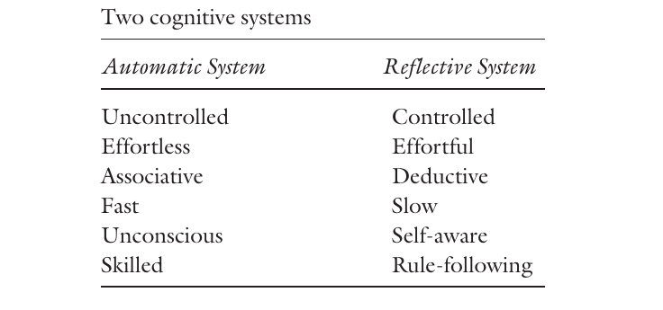

(taken from Thaler & Sunstein, 2008, p. 20)

## Dual-Processes and Moral Dumbfounding

> Cillian McHugh - 19/11/21
- Dual-process theories of moral judgement
- Conflict in dual-process occurs when
  - a habitual (System 1) response is different
  - from a response that results from deliberation (System 2)
- Three response options in the dumbfounding paradigm
  - It’s wrong and I can provide a valid reason
  - It’s wrong but I can’t think of a reason
  - There is nothing wrong (competing intuitions)

(Crockett, 2013; Cushman, 2013; Evans, 2007; Evans & Stanovich, 2013; Greene, 2008)

## Dual-Processes and Moral Dumbfounding

> Cillian McHugh - 19/11/21
- Dual-process theories of moral judgement
- Conflict in dual-process occurs when
  - a habitual (System 1) response is different
  - from a response that results from deliberation (System 2)
- Three response options in the dumbfounding paradigm
  - It’s wrong and I can provide a valid reason
  - It’s wrong but I can’t think of a reason
  - There is nothing wrong (competing intuitions)

(Crockett, 2013; Cushman, 2013; Evans, 2007; Evans & Stanovich, 2013; Greene, 2008)

## Dual-Processes and Moral Dumbfounding

> Cillian McHugh - 19/11/21
- Dual-process theories of moral judgement
- Conflict in dual-process occurs when
  - a habitual (System 1) response is different
  - from a response that results from deliberation (System 2)
- Three response options in the dumbfounding paradigm
  - **It’s wrong and I can provide a valid reason**
  - It’s wrong but I can’t think of a reason
  - There is nothing wrong (competing intuitions)

(Crockett, 2013; Cushman, 2013; Evans, 2007; Evans & Stanovich, 2013; Greene, 2008)

## Dual-Processes and Moral Dumbfounding

> Cillian McHugh - 19/11/21
- Dual-process theories of moral judgement
- Conflict in dual-process occurs when
  - a habitual (System 1) response is different
  - from a response that results from deliberation (System 2)
- Three response options in the dumbfounding paradigm
  - It’s wrong and I can provide a valid reason
  - **It’s wrong but I can’t think of a reason**
  - There is nothing wrong (competing intuitions)

(Crockett, 2013; Cushman, 2013; Evans, 2007; Evans & Stanovich, 2013; Greene, 2008)

## Dual-Processes and Moral Dumbfounding

> Cillian McHugh - 19/11/21
- Dual-process theories of moral judgement
- Conflict in dual-process occurs when
  - a habitual (System 1) response is different
  - from a response that results from deliberation (System 2)
- Three response options in the dumbfounding paradigm
  - It’s wrong and I can provide a valid reason
  - It’s wrong but I can’t think of a reason
  - **There is nothing wrong (competing intuitions)**

(Crockett, 2013; Cushman, 2013; Evans, 2007; Evans & Stanovich, 2013; Greene, 2008)

## Dual-Processes and Moral Dumbfounding

> Cillian McHugh - 19/11/21
- Dual-process theories of moral judgement
- Conflict in dual-process occurs when
  - a habitual (System 1) response is different
  - from a response that results from deliberation (System 2)
- Three response options in the dumbfounding paradigm
  - It’s wrong and I can provide a valid reason
  - It’s wrong but I can’t think of a reason
  - There is nothing wrong (competing intuitions)

(Crockett, 2013; Cushman, 2013; Evans, 2007; Evans & Stanovich, 2013; Greene, 2008)

## Cognitive Load and Moral Dumbfounding

> Cillian McHugh - 19/11/21
- Manipulations of Cognitive load are known to inhibit deliberative responding
- Recall the three response options in dumbfounding
  - (a) It’s wrong and I can provide a valid reason
  - (b) It’s wrong but I can’t think of a reason
  - (c) There is nothing wrong (competing intuitions)

**Cognitive load & dumbfounded responding**

**↓** **↓** **↓** **↓** Giving reasons (a) **↓** **↓** **↓** **↓**

**↑** **↑** Dumbfounded responding (b) **↑** **↑** **↑**

**↑** **↑** There is nothing wrong (c) **↑**

## Individual Differences in Moral Dumbfounding

> Cillian McHugh - 19/11/21
- Dumbfounded responding may be linked with individual differences
- Need for Cognition has been linked to dual-process approaches to cognition
- The Need for Cognition Scale (NFC) is a measure of an individual’s tendency  
  *“to engage in and enjoy effortful analytic activity”*

(Forsterlee & Ho, 1999, p. 471; see also Cacioppo & Petty, 1982)

- tendency to engage in deliberation
- a person’s need to understand and make sense of the world

(Cacioppo & Petty, 1982; Evans & Stanovich, 2013; Forsterlee & Ho, 1999; Petty, Cacioppo, & Kao, 1984; Petty, Feinstein, Blair, & Jarvis, 1996)

## Individual Differences in Moral Dumbfounding

> Cillian McHugh - 19/11/21

### We hypothesised:

- People who score highly on the NFC
  - will be more likely to provide reasons for their judgement
- People who score low on the NFC
  - are likely to fail to identify reasons for their judgement
- NFC is related to a need to understand and make sense of the world
  - Of the people who fail to identify reasons for their judgement:
    - those who revise their judgement will likely score higher on the NFC than people who provide a dumbfounded response

## Cognitive Load Manipulations (Studies 1 & 5)

> Cillian McHugh - 19/11/21

[figure not shown]

## Cognitive Load Manipulations (Studies 2, 3, & 4)

> Cillian McHugh - 19/11/21

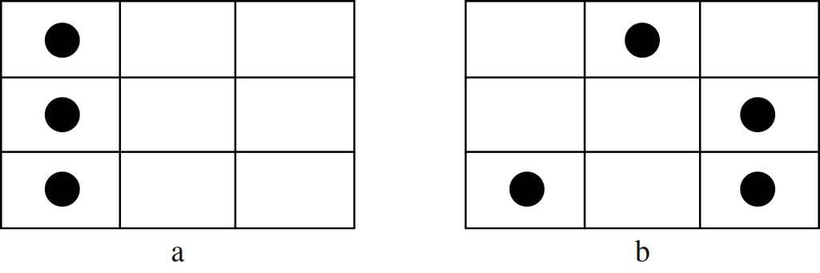

Sample dot patterns

(scored out of 9; 1 misplaced dot = 7/9)

(taken from De Neys & Schaeken, 2007)

## Study 1: Results

> Cillian McHugh - 19/11/21

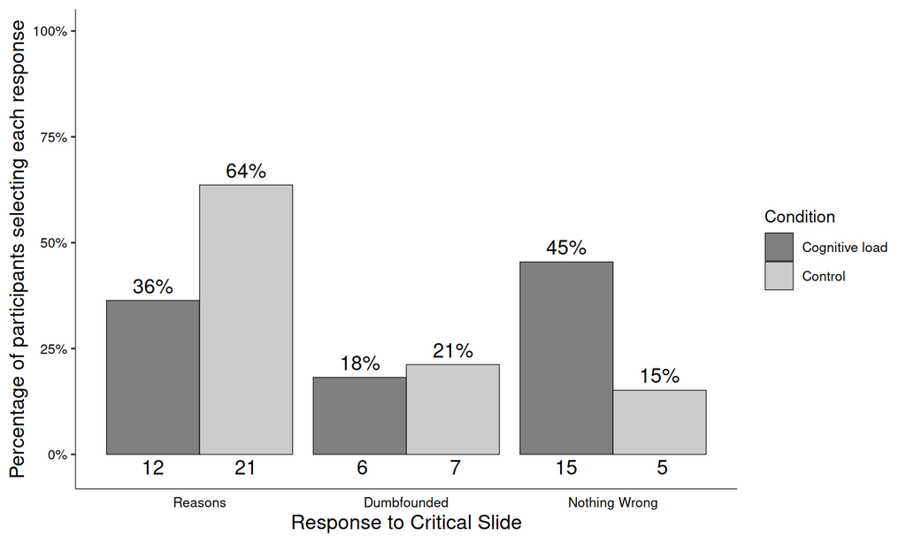

## Study 2: Results

> Cillian McHugh - 19/11/21

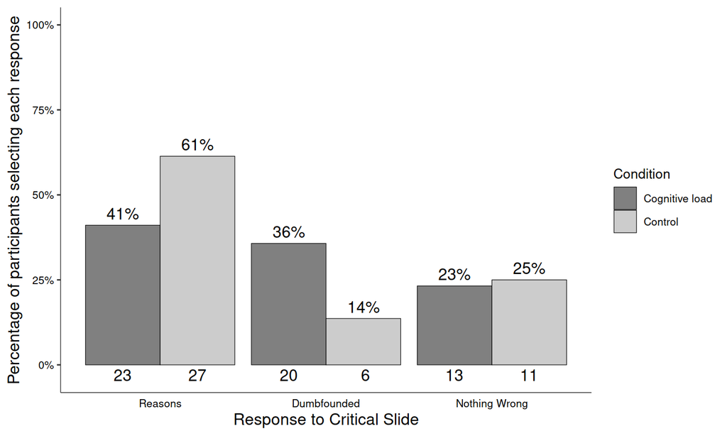

## Study 3: Results

> Cillian McHugh - 19/11/21

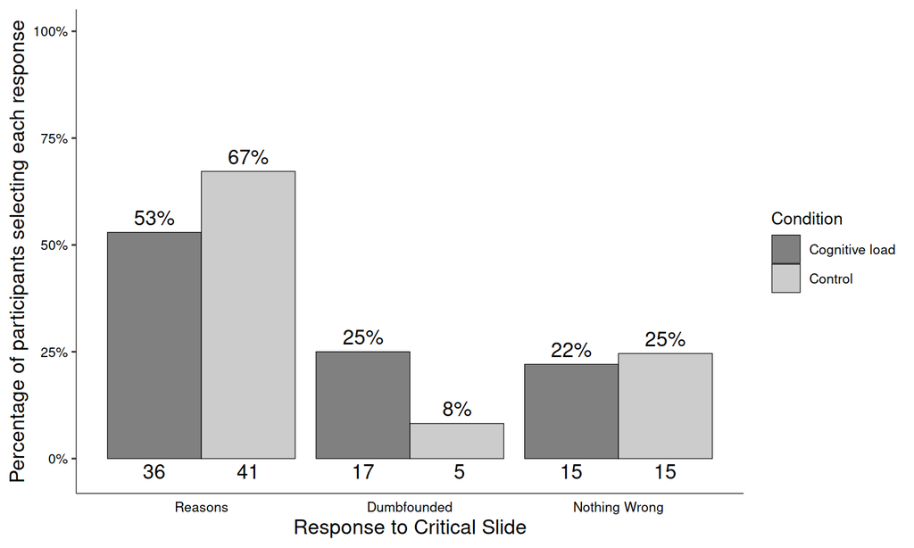

## Study 4: Results

> Cillian McHugh - 19/11/21

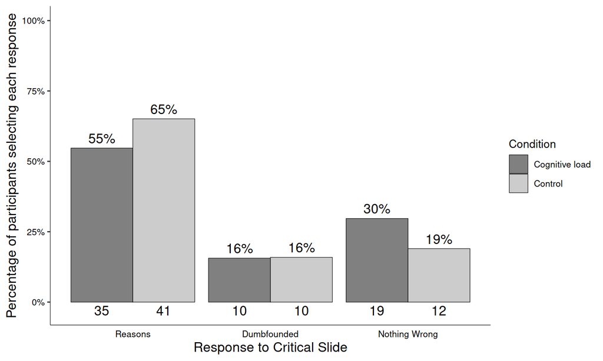

## Study 5: Results

> Cillian McHugh - 19/11/21

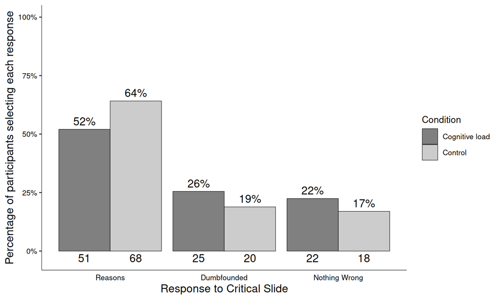

## Combined Results

> Cillian McHugh - 19/11/21

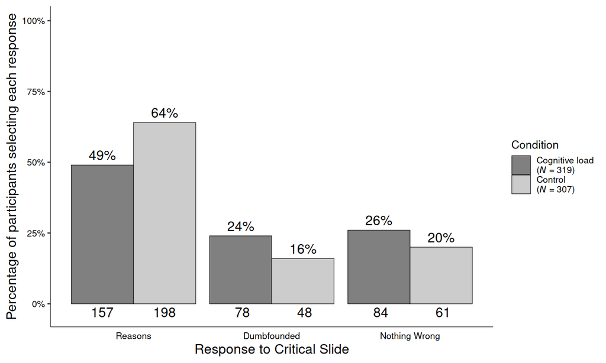

## Combined Results

> Cillian McHugh - 19/11/21

```
##
##  Pearson's Chi-squared test
##
## data:  table(df3$InCS, df3$condition)
## X-squared = 9.79, df = 2, p-value = 0.007484
```

[output not shown]

## Meta-Analysis

> Cillian McHugh - 19/11/21
- A mini meta-analysis found that cognitive load significantly influenced responding across all studies
  - χ<sup>2</sup>(10) = 26.882, *p* = .003 (Fisher’s method)
  - when weighting for sample size, *z* = 2.874, *p* = .002 (Stouffer’s Z-score method)

## Cognitive Load and Dumbfounded Responding

> Cillian McHugh - 19/11/21

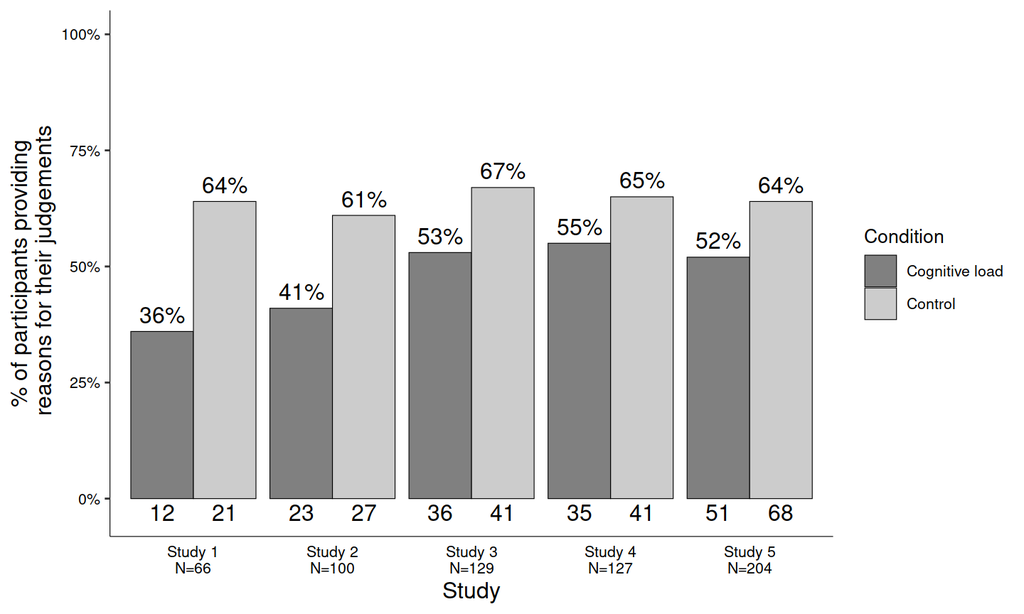

## Need for Cognition

> Cillian McHugh - 19/11/21
- Significant association between Need for Cognition and response to the critical slide
  - χ<sup>2</sup>(2, *N* = 654) = 12.15, *p* = .002, The observed power was 0.89.
- Need for Cognition explained between 0.48% (Cox and Snell R square) and 0.72% (Nadelkerke R squared) of the variance in responses to the critical slide.
- As Need for Cognition increased, participants were significantly more likely to provide reasons than to present as dumbfounded:
  - Wald = 11.01, *p* < .001, odds ratio = 1.27, 95% CI [1.1, 1.46]
- As Need for Cognition increased, participants were also significantly more likely to select there is nothing wrong than present as dumbfounded Wald = 7.86, *p* = .005, odds ratio = 1.27, 95% CI [1.07, 1.5].

## Need for Cognition

> Cillian McHugh - 19/11/21

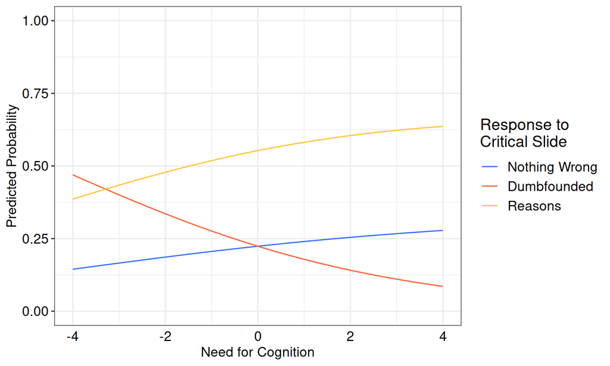

*Probability of each response depending on Need for Cognition*

## Manuscript Progress

- 26th December 2019: Rejected at JESP (despited endorsement from Roger)
- 4th May 2020: Rejected at JEP:G
- Looking for more reliable method
- Planning high-powered replication
  - Large sample
  - Reliable participant pool
- Needed €€€€€
  - SPSP research grand unsuccessful
  - EHS Seed Funding Success

## Study 6

## New Manipulation:

> Cillian McHugh - 19/11/21

[interactive chart not shown]

## Sample Make-up

```
## [1] 1899
```

```
##
## cog_load  control
##      913      885
```

```
##
##  UK  US
## 963 936
```

```
##
##            Heinz Incest Jennifer Trolley
##   cog_load   219    232      237     225
##   control    222    220      226     217
```

## Cleaned Data

```
## [1] 1686
```

```
##
## cog_load  control
##      826      860
```

```
##
##  UK  US
## 842 844
```

```
##
##            Heinz Incest Jennifer Trolley
##   cog_load   203    197      218     208
##   control    215    215      214     216
```

## Effect of Cognitive Load (full sample)

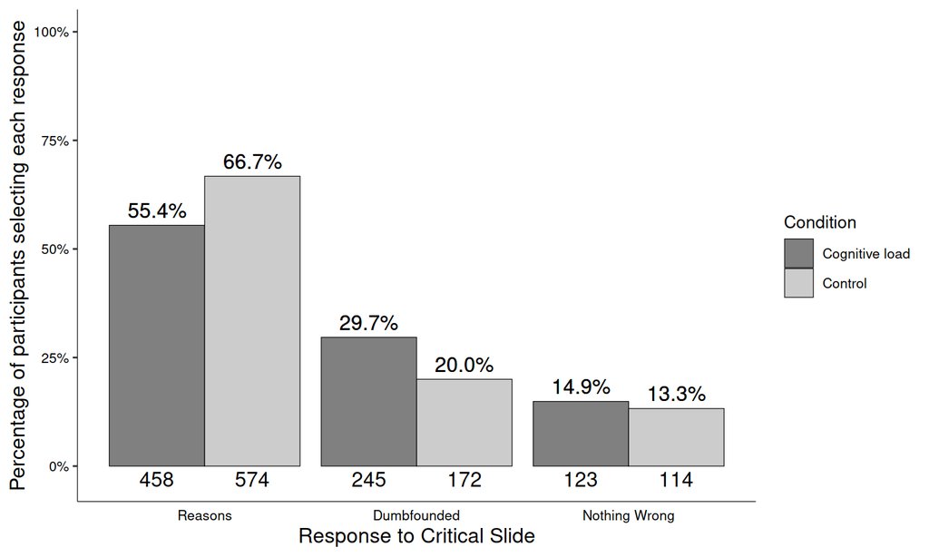

Study 6: Responses to critical slide depending on Cognitive Load

## Testing: Full Sample

```
##                                              N   %   N   %
## It's wrong and I can provide a valid reason. 458 55% 574 67%
## It's wrong but I can't think of a reason.    245 30% 172 20%
## There is nothing wrong.                      123 15% 114 13%
```

```
##
##  Pearson's Chi-squared test
##
## data:  table(df3$InCS, df3$condition)
## X-squared = 25.485, df = 2, p-value = 2.925e-06
```

## Residuals: Full Sample

```
##                                        Cognitive Load Control
## 1         Observed count       Reasons            458     574
## 2                          Dumbfounded            245     172
## 3                        Nothing Wrong            123     114
## 4         Expected count       Reasons         505.59  526.41
## 5                          Dumbfounded          204.3   212.7
## 6                        Nothing Wrong         116.11  120.89
## 7 Standardised residuals       Reasons        -4.76**  4.76**
## 8                          Dumbfounded          4.6**  -4.6**
## 9                        Nothing Wrong           0.97   -0.97
```

## Julie and Mark

### Sample size (with breakdown)

```
## [1] 412
```

```
##
##  UK  US
## 207 205
```

```
##
## cog_load  control
##      197      215
```

## Effect of Cognitive Load (Julie & Mark)

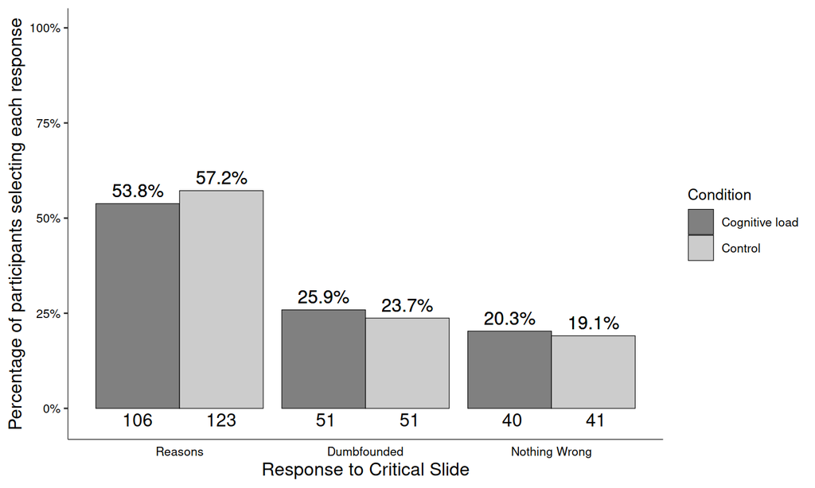

Study 6: Responses to critical slide depending on Cogniitve Load (Julie & Mark)

## Testing: Julie & Mark

```
##                                              N   %   N   %
## It's wrong and I can provide a valid reason. 106 54% 123 57%
## It's wrong but I can't think of a reason.    51  26% 51  24%
## There is nothing wrong.                      40  20% 41  19%
```

```
##
##  Pearson's Chi-squared test
##
## data:  table(df3$InCS, df3$condition)
## X-squared = 0.48888, df = 2, p-value = 0.7831
```

## Residuals: Julie & Mark

```
##                                        Cognitive Load Control
## 1         Observed count       Reasons         106.00  123.00
## 2                          Dumbfounded          51.00   51.00
## 3                        Nothing Wrong          40.00   41.00
## 4         Expected count       Reasons         109.50  119.50
## 5                          Dumbfounded          48.77   53.23
## 6                        Nothing Wrong          38.73   42.27
## 7 Standardised residuals       Reasons          -0.69    0.69
## 8                          Dumbfounded           0.51   -0.51
## 9                        Nothing Wrong           0.32   -0.32
```

## Jennifer

### Sample size (with breakdown)

```
## [1] 432
```

```
##
##  UK  US
## 212 220
```

```
##
## cog_load  control
##      218      214
```

## Effect of Cognitive Load (Jennifer)

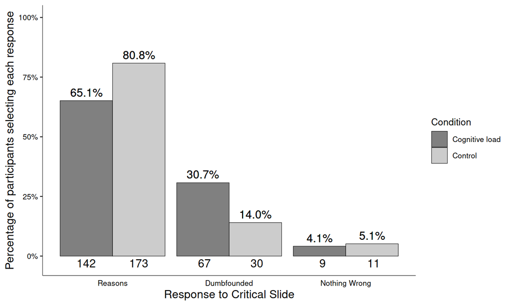

Study 6: Responses to critical slide depending on Cogniitve Load (Jennifer)

## Testing: Jennifer

```
##                                              N   percent N   percent
## It's wrong and I can provide a valid reason. 142 65%     173 81%
## It's wrong but I can't think of a reason.    67  31%     30  14%
## There is nothing wrong.                      9   4%      11  5%
```

```
##
##  Pearson's Chi-squared test
##
## data:  table(df3$InCS, df3$condition)
## X-squared = 17.329, df = 2, p-value = 0.0001726
```

## Residuals: Jennifer

```
##                                        Cognitive Load Control
## 1         Observed count       Reasons            142     173
## 2                          Dumbfounded             67      30
## 3                        Nothing Wrong              9      11
## 4         Expected count       Reasons         158.96  156.04
## 5                          Dumbfounded          48.95   48.05
## 6                        Nothing Wrong          10.09    9.91
## 7 Standardised residuals       Reasons        -3.67**  3.67**
## 8                          Dumbfounded         4.16** -4.16**
## 9                        Nothing Wrong           -0.5     0.5
```

## Trolley

### Sample size (with breakdown)

```
## [1] 424
```

```
##
##  UK  US
## 218 206
```

```
##
## cog_load  control
##      208      216
```

## Effect of Cognitive Load (Trolley)

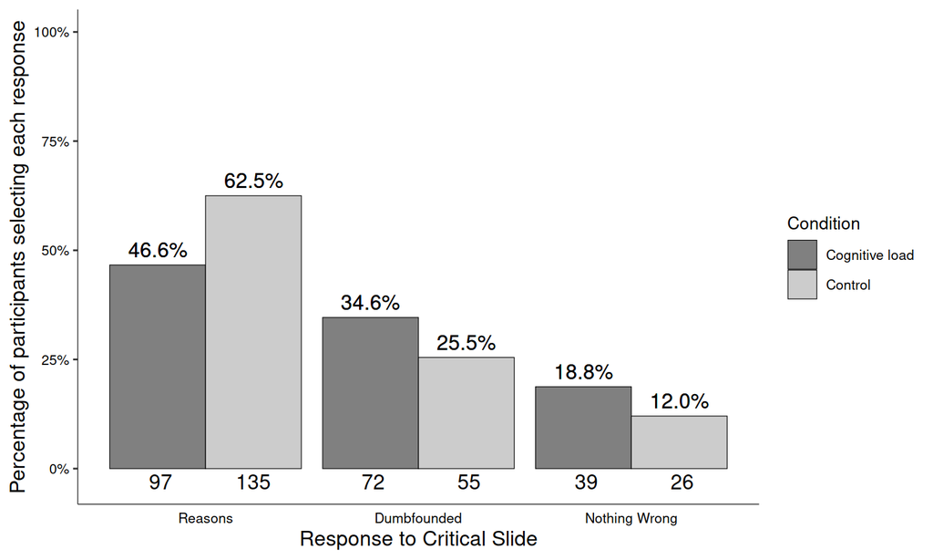

Study 6: Responses to critical slide depending on Cogniitve Load (Trolley)

## Testing: Trolley

```
##                                              N  percent N   percent
## It's wrong and I can provide a valid reason. 97 47%     135 62%
## It's wrong but I can't think of a reason.    72 35%     55  25%
## There is nothing wrong.                      39 19%     26  12%
```

```
##
##  Pearson's Chi-squared test
##
## data:  table(df3$InCS, df3$condition)
## X-squared = 10.953, df = 2, p-value = 0.004185
```

## Residuals: Trolley

```
##                                        Cognitive Load Control
## 1         Observed count       Reasons             97     135
## 2                          Dumbfounded             72      55
## 3                        Nothing Wrong             39      26
## 4         Expected count       Reasons         113.81  118.19
## 5                          Dumbfounded           62.3    64.7
## 6                        Nothing Wrong          31.89   33.11
## 7 Standardised residuals       Reasons         -3.28*   3.28*
## 8                          Dumbfounded          2.06*  -2.06*
## 9                        Nothing Wrong           1.92   -1.92
```

## Heinz

### Sample size (with breakdown)

```
## [1] 418
```

```
##
##  UK  US
## 205 213
```

```
##
## cog_load  control
##      203      215
```

## Effect of Cognitive Load (Heinz)

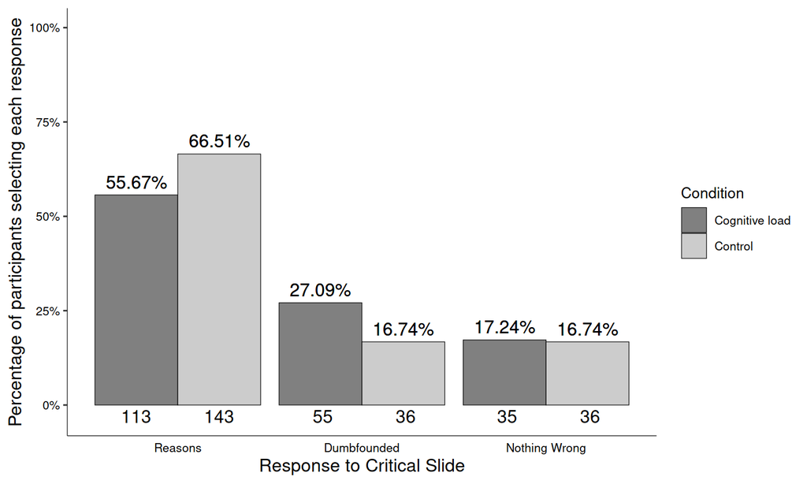

Study 6: Responses to critical slide depending on Cogniitve Load (Heinz)

## Testing: Heinz

```
##                                              N   percent N   percent
## It's wrong and I can provide a valid reason. 113 56%     143 67%
## It's wrong but I can't think of a reason.    55  27%     36  17%
## There is nothing wrong.                      35  17%     36  17%
```

```
##
##  Pearson's Chi-squared test
##
## data:  table(df3$InCS, df3$condition)
## X-squared = 7.1581, df = 2, p-value = 0.0279
```

## Residuals: Heinz

```
##                                        Cognitive Load Control
## 1         Observed count       Reasons            113     143
## 2                          Dumbfounded             55      36
## 3                        Nothing Wrong             35      36
## 4         Expected count       Reasons         124.33  131.67
## 5                          Dumbfounded          44.19   46.81
## 6                        Nothing Wrong          34.48   36.52
## 7 Standardised residuals       Reasons         -2.27*   2.27*
## 8                          Dumbfounded          2.56*  -2.56*
## 9                        Nothing Wrong           0.14   -0.14
```

## All Scenarios

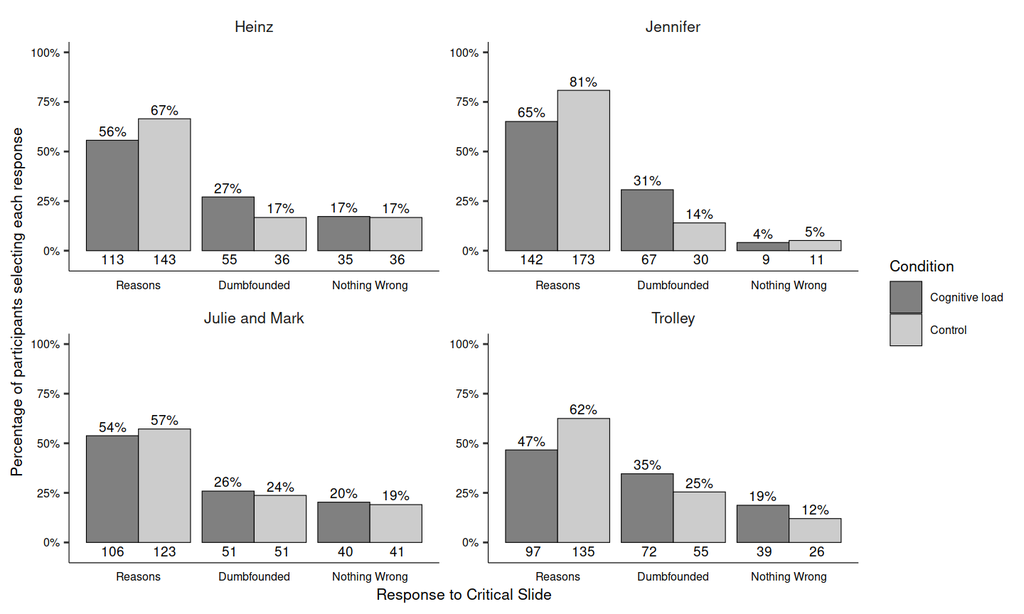

Study 6: Responses depending on Cognitive Load for each scenario

## References

Cacioppo, J. T., & Petty, R. E. (1982). The need for cognition. *Journal of Personality and Social Psychology*, *42*(1), 116–131. https://doi.org/10.1037/0022-3514.42.1.116

Crockett, M. J. (2013). Models of morality. *Trends in Cognitive Sciences*, *17*(8), 363–366. https://doi.org/10.1016/j.tics.2013.06.005

Cushman, F. A. (2013). Action, Outcome, and Value A Dual- System Framework for Morality. *Personality and Social Psychology Review*, *17*(3), 273–292. https://doi.org/10.1177/1088868313495594

De Neys, W., & Schaeken, W. (2007). When people are more logical under cognitive load: Dual task impact on scalar implicature. *Experimental Psychology*, *54*(2), 128–133. https://doi.org/10.1027/1618-3169.54.2.128

Evans, J. St. B. T. (2007). On the resolution of conflict in dual process theories of reasoning. *Thinking & Reasoning*, *13*(4), 321–339. https://doi.org/10.1080/13546780601008825

Evans, J. St. B. T., & Stanovich, K. E. (2013). Dual- Process Theories of Higher Cognition: Advancing the Debate. *Perspectives on Psychological Science*, *8*(3), 223–241. https://doi.org/10.1177/1745691612460685

Forsterlee, R., & Ho, R. (1999). An Examination of the Short form of the Need for Cognition Scale Applied in an Australian Sample. *Educational and Psychological Measurement*, *59*(3), 471–480. https://doi.org/10.1177/00131649921969983

Greene, J. D. (2008). The Secret Joke of Kant’s Soul. In W. Sinnott-Armstrong, *Moral Psychology Volume 3: The neurosciences of morality: Emotion, brain disorders, and development* (pp. 35–79). Cambridge (Mass.): the MIT press.

Petty, R. E., Cacioppo, J. T., & Kao, C. F. (1984). The efficient assessment of need for cognition. *Journal of Personality Assessment*, *48*(3), 306–307.

Petty, R. E., Feinstein, J. A., Blair, W., & Jarvis, G. (1996). Dispositional differences in cognitive motivation: The life and times of individuals varying in need for cognition. *Psych. Bull*, 197–253.

Thaler, R. H., & Sunstein, C. R. (2008). *Nudge: Improving decisions about health, wealth, and happiness*. New Haven: Yale University Press.